# SDS2 - Project

Alessandro Flaborea

17 luglio 2019

# Introduction

The purpose of this project is to provide a bayesian analysis on some real data, with the use of MCMC simulations within the OpenBUGS software. The analysis will focus on a linear regression on the data ‘[Small Area Estimation of Average Income](https://sites.google.com/a/r-inla.org/stbook/datasets)’.

# Data

The dataset was taken from the book [Spatial and Spatio-temporal Bayesian models with R-INLA](https://sites.google.com/a/r-inla.org/stbook/datasets), which contains a lot of examples for bayesian analysis. The dataset consists of informations about 284 municipalities in Sweden. We have:

- One response, INCOME: is the average annual household income in area

$$I N C O M E_{i}=\sum_{j=1}^{n_{i}} \frac{W_{i j} y_{i j}}{\sum w_{i j}};\ w_{i j}\ sampling\ weights$$

- Two predictors
  - AVAGE: average age of heads of the households
  - RURAL: rurality level of the area (1: urban, 2:mixed, 3:rural)

```r
income <- read_csv("income.csv")
```

```r
print(head(income))
```

```
## # A tibble: 6 x 3
##   income   age rural
##    <dbl> <dbl> <int>
## 1  1673.  37.4     2
## 2  1743.  39.4     2
## 3  1747.  40.6     2
## 4  1735.  40.7     2
## 5  1749.  41.4     2
## 6  1732.  43.1     2
```

The graph below shows how the responde feature Income is distributed. We can simply say that it is distributed as a Normal.

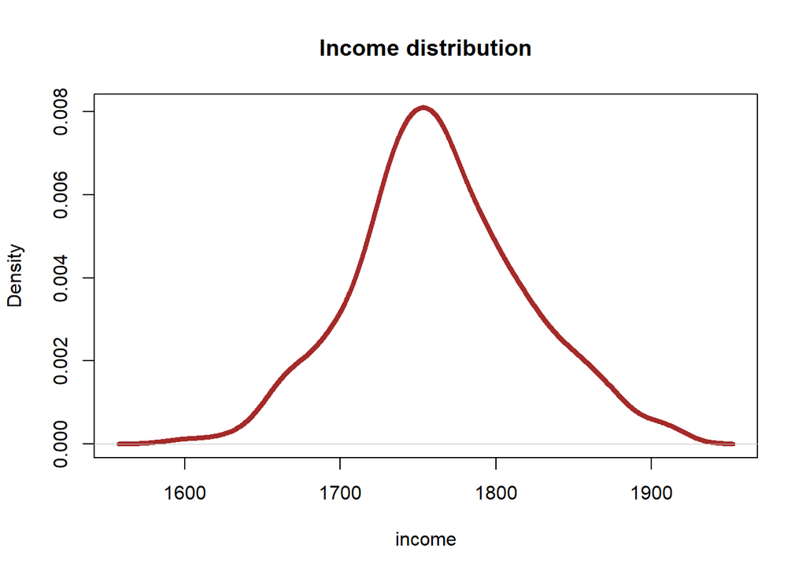

```r
plot(density(income$income), col = 'brown', lwd= 4, main = 'Income distribution', xlab = 'income' )
```

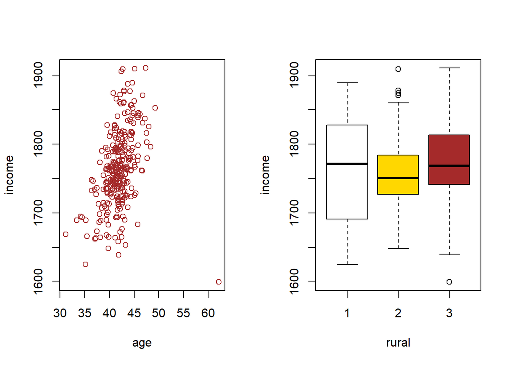

```r
par(mfrow=  c(1,2))

plot(x = income$age, y = income$income, col = c('brown'), xlab = 'age', ylab = 'income')
boxplot(income$income~income$rural, col = c('white', 'gold', 'brown'), xlab = 'rural', ylab = 'income')
```

```r
cor(income)
```

```
##           income       age    rural
## income 1.0000000 0.3840357 0.139982
## age    0.3840357 1.0000000 0.270994
## rural  0.1399820 0.2709940 1.000000
```

Their correlation is 0.38, that means that they have a significant correlation.

We can not say the same thing for the couple Income-Rural. They have a correlation of 0.14 and, as the graph shows, it is not clear how the income values change according to different rurality level of the area.

## Model

Since we are dealing with a linear regression and knowing that the response is distributed as a Normal, we can use the following model:

$$\text {INCOME}_{i} \sim \operatorname{Normal}\left(\mu_{i}, \sigma^{2}\right),\ i = 1, ..., 284\\
\mu_{i}=\alpha+\beta \times \text { AVAGE }_{i}\ +< \text {effect of RURAL}>\\
1 / \sigma^{2} \sim \operatorname{Gamma}(0.001,0.001)\\
\alpha \sim \operatorname{Normal}(0,100000)\\
\beta \sim \text { Normal( } 0,100000 )\\
\text {Prior on coefficients for RURAL effect}$$

As we can see the priors all have parameters to make them non-informative.

# OpenBUGS simulation

This section contains both the initialization part of our simulation, such as model specification, input data and starting values for the MCMC, and the results given by the simulation.

## Model Specification

The model described above translated in the BUGS language.

```r
model{

  for( i in 1 : N ) {
    INCOME[i] ~ dnorm(mu[i], tau)
    mu[i] <- alpha + beta*(AVAGE[i]-mean(AVAGE[])) + delta[RURAL[i]]
  }

  alpha ~ dnorm(0, 0.00001)
  beta ~ dnorm(0, 0.00001)
  delta[1] <- 0
  delta[2] ~ dnorm(0, 0.00001)
  delta[3] ~ dnorm(0, 0.00001)
  tau ~ dgamma(0.001, 0.001); sigma2 <- 1/tau

}
```

## Data

Due to its length, the data initialization is in the Appendix 1 at the end of the analysis.

## Starting values

These values are needed for the initialization of the MCMC. In this case, two chains are used in order to check if there is convergence or not.

```r
list(alpha = 1, beta = -2, delta = c(NA, -2, 4),  tau = 2)
list(alpha = 2, beta = -1, delta = c(NA, -3, 3),  tau = 1)
```

## Outcomes

After an initial burnin of 1000 iterations, the parameters $beta$ and the two $delta$ are monitored after 10000 iterations.

Here we can see beta:

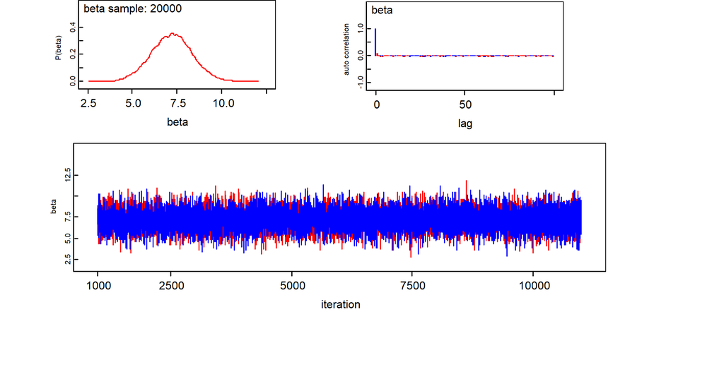

Looking at the trace and autocorrelation plots, it can be said that it converged.

And here are the plots for the delta:

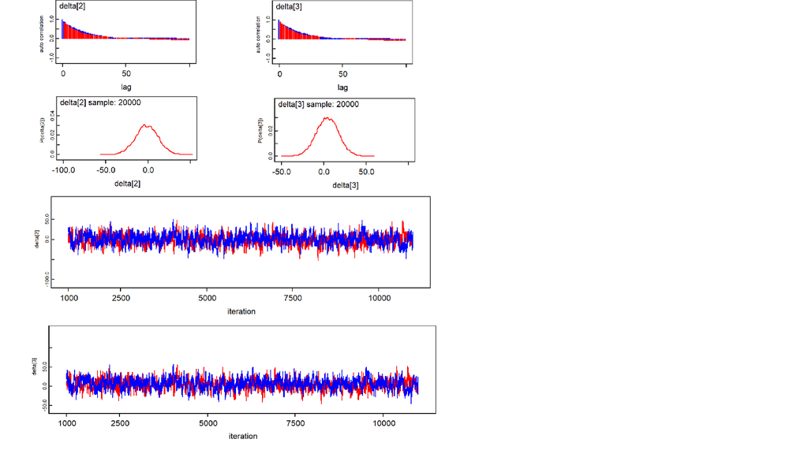

In contrast with the beta’s plots, here the autocorrelation has highest values and the two trace plots does not overlap as in the previous case. This means that the convergence is achieved but the variance of the values is really high.

In this table we can see a lot of interesting values:

|  | mean | sd | MC_error | val2.5pc | median | val97.5pc | start | sample |
| --- | --- | --- | --- | --- | --- | --- | --- | --- |
| beta | 7.202 | 1.147 | 0.008601 | 4.923 | 7.215 | 9.454 | 1001 | 20000 |
| delta[2] | -1.193 | 13.27 | 0.4677 | -27.39 | -1.213 | 24.92 | 1001 | 20000 |
| delta[3] | 4.751 | 13.35 | 0.4691 | -21.42 | 4.785 | 31.19 | 1001 | 20000 |

We can see that the estimated Standard Deviations and the error of the MCMC simulation is really bigger for the delta parameters than the beta one, which means that for the deltas the precision is low.

## Hypothesis Testing

Another important aspect of the stats table that we can focus on, is the 95% confidence interval. In fact we can see that the deltas’ C.I. are delta[2] = (-27.39, 24.92) and delta[3] = (-21.42, 31.19).

We assume that our null hypothesys and the alternative hypothesis are:

$$H_0: Mixed - RURAL = 0\ and\ Urban - RURAL = 0$$

$$H_1: Mixed - RURAL \neq 0\ and\ Urban - RURAL \neq 0$$

We know that if the 95% confidence interval contains zero, then the effect will not be significant at the 0.05 level. This means that if the C.I. contains zero, the null hyphotesis can not be rejected.

For this reason, both the deltas’ C.I. contain zero so we can discard the predictor RURAL, because it is not significant for the final prediction.

# Analysis without the RURAL predictor

Once we have stated that the RURAL predictor has no statistical significance, we redo the simulations without it and trying to point out the differences and, if present, the improvements.

## Model Specification

Here there is the same model as before with the only difference that RURAL is not used as a predictor for INCOME.

```r
model{

  for( i in 1 : N ) {
    INCOME[i] ~ dnorm(mu[i], tau)
    mu[i] <- alpha + beta*(AVAGE[i]-mean(AVAGE[]))
  }

  alpha ~ dnorm(0, 0.00001)
  beta ~ dnorm(0, 0.00001)
  tau ~ dgamma(0.001, 0.001); sigma2 <- 1/tau
  dummy <- RURAL[1]
}
```

## Data

As before, it is in the Appendix 1.

## Starting values

Same as in the previous section, except for the delta initializations of RURAL that are not needed.

```r
list(alpha = 1, beta = -2, tau = 2)
list(alpha = 2, beta = -1, tau = 1)
```

## Outcomes

The only monitored parameter is beta:

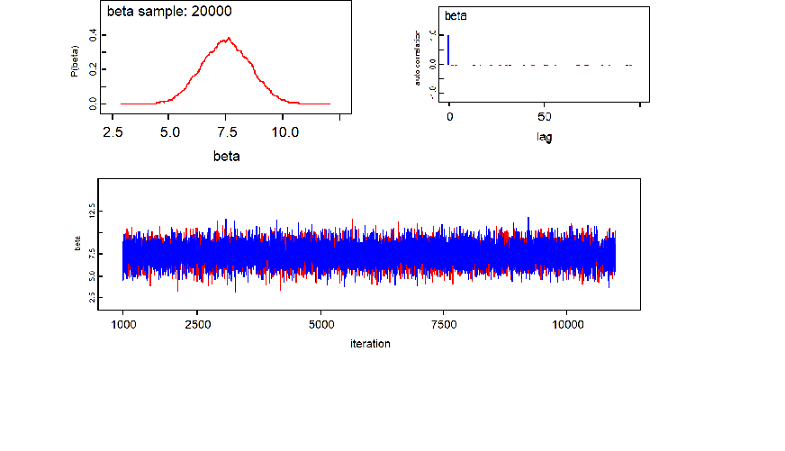

As in the previous case, beta converges almost immediately and, looking at the following stats, we can say that there is a decrease in the standard deviation and on the MC error.

|  | mean | sd | MC_error | val2.5pc | median | val97.5pc | start | sample |
| --- | --- | --- | --- | --- | --- | --- | --- | --- |
| beta | 7.514 | 1.087 | 0.008134 | 5.389 | 7.517 | 9.64 | 1001 | 20000 |

# Analysis on Alpha

Now we take a look at the parameter alpha with and without the RURAL predictor looking for changes between the two simulations.

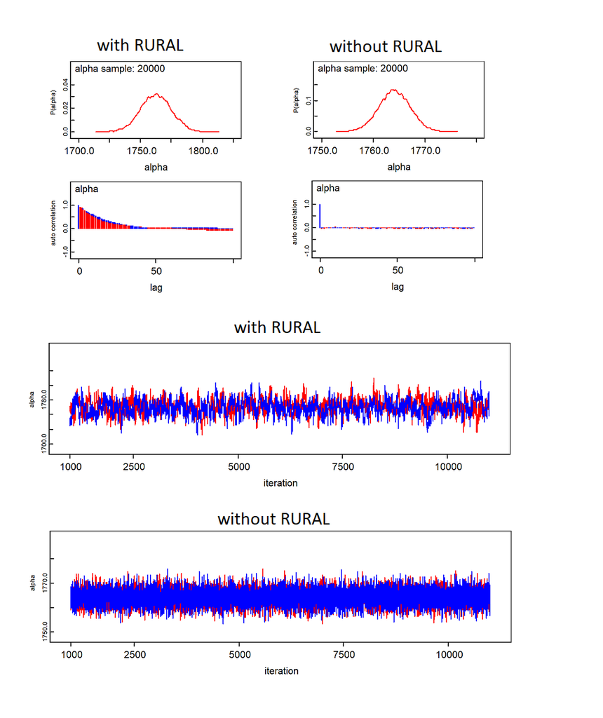

From the plots above it can be seen a really huge difference. If we can clearly see a convergence when we does not have a the RURAL predictor, we can also state that in the other case the convergence is more difficult to be found because, as said before, the range of the values is wide. Even the following table points out some other informations:

|  | mean | sd | MC_error | val2.5pc | median | val97.5pc | start | sample |
| --- | --- | --- | --- | --- | --- | --- | --- | --- |
| alpha_with | 1763.0 | 12.54 | 0.4543 | 1738.0 | 1763.0 | 1787.0 | 1001 | 20000 |
| alpha_without | 1764.0 | 3.053 | 0.02302 | 1758.0 | 1764.0 | 1770.0 | 1001 | 20000 |

The alpha-with-RURAL’s standard deviation and MC error are higher than alpha-without-RURAL’s. Also the confidence intervals reflect this path, in fact the alpha-without’s one is way thinner than the other.

# Bayes vs Inference

In this section we are going to analyse the differencences between the inferential approach and the bayesian one.

We do two inferential linear regression: one with both the predictors on the data used before and the other without the rural predictor.

```r
income$age <- income$age - mean(income$age)
model <- lm(income ~ age + rural , data = income)
model_without <- lm(income ~ age , data = income)
```

```r
pred.int <- predict(model, interval = "confidence")
pred.int_without <- predict(model_without, interval = "confidence")
```

```r
mydata <- cbind(income, pred.int)
mydata_without <- cbind(subset( income, select = -rural), pred.int_without)



summary(model)
```

```
##
## Call:
## lm(formula = income ~ age + rural, data = income)
##
## Residuals:
##      Min       1Q   Median       3Q      Max
## -314.432  -28.124   -3.506   31.799  139.982
##
## Coefficients:
##             Estimate Std. Error t value Pr(>|t|)
## (Intercept) 1755.732     13.112 133.904  < 2e-16 ***
## age            7.302      1.118   6.533 3.01e-10 ***
## rural          3.621      5.342   0.678    0.498
## ---
## Signif. codes:  0 '***' 0.001 '**' 0.01 '*' 0.05 '.' 0.1 ' ' 1
##
## Residual standard error: 51.27 on 281 degrees of freedom
## Multiple R-squared:  0.1489, Adjusted R-squared:  0.1428
## F-statistic: 24.58 on 2 and 281 DF,  p-value: 1.459e-10
```

```r
summary(model_without)
```

```
##
## Call:
## lm(formula = income ~ age, data = income)
##
## Residuals:
##     Min      1Q  Median      3Q     Max
## -316.37  -27.85   -3.21   31.40  138.42
##
## Coefficients:
##             Estimate Std. Error t value Pr(>|t|)
## (Intercept) 1764.378      3.039 580.513  < 2e-16 ***
## age            7.507      1.075   6.985 2.05e-11 ***
## ---
## Signif. codes:  0 '***' 0.001 '**' 0.01 '*' 0.05 '.' 0.1 ' ' 1
##
## Residual standard error: 51.22 on 282 degrees of freedom
## Multiple R-squared:  0.1475, Adjusted R-squared:  0.1445
## F-statistic: 48.79 on 1 and 282 DF,  p-value: 2.055e-11
```

From the summary of the models printed above, we can derive some interesting informations. First of all we can see that in the first model (the one with all the predictors), like the bayesian one, RURAL has no significance for our regression and does not have any effect on our predictions.

Another important information is shown in the following table:

|  | mean | sd |
| --- | --- | --- |
| beta_with | 7.202 | 1.147 |
| beta_without | 7.514 | 1.087 |
| beta_infer | 7.302 | 1.118 |
| beta_infer_without | 7.507 | 1.075 |

In the case of the age predictor (beta) the variations between the cases are not so visible. The four values lay all around $(7.2, 7.5)$, all with standard deviations close to one.

A big difference can be seen here, where the values of the intercept alpha are shown:

|  | mean | sd |
| --- | --- | --- |
| alpha_with | 1763.0 | 12.54 |
| alpha_without | 1764.0 | 3.053 |
| alpha_infer | 1755.73 | 13.11 |
| alpha_infer_without | 1764.38 | 3.039 |

In the case of alpha we can state that the four mean values are all around the same interval, but the standard deviation is really smaller when the predictor RURAL is not used in the model. In fact, both the inferential and the bayesian alpha have a SD four time lower than the others.

The following plots want to show visually the fit of the regression in the three ways analyzed untill now.

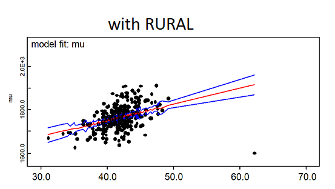

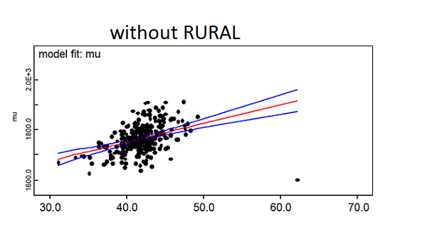

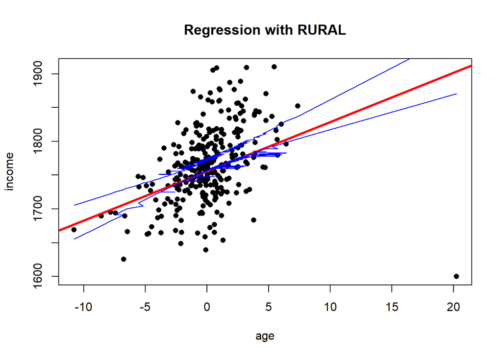

```r
x <- data.frame("age" = income$age, "pred" = pred.int[,2])
x <- x[order(-x$pred),]
xx <- data.frame("age" = income$age, "pred" = pred.int[,3])
xx <- xx[order(-xx$pred),]

plot(income$age, income$income, main="Regression with RURAL", col = 'black', pch = 16,xlab= 'age', ylab='income')
abline(a = model$coefficients[1], b = model$coefficients[2], col="red", lwd = 3)

lines(x$age, x$pred, col="blue")
lines(xx$age, xx$pred, col="blue")
```

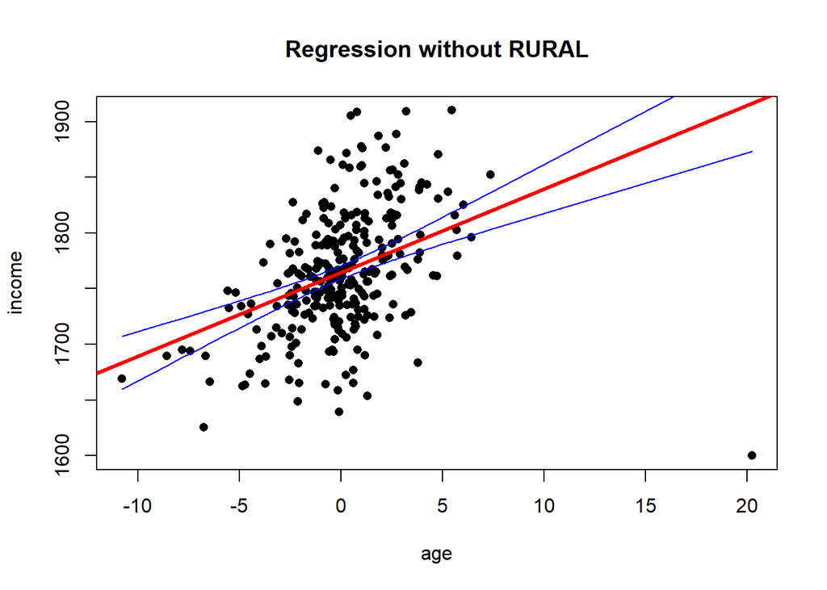

```r
x_w <- data.frame("age" = income$age, "pred" = pred.int_without[,2])
x_w <- x_w[order(-x_w$pred),]
xx_w <- data.frame("age" = income$age, "pred" = pred.int_without[,3])
xx_w <- xx_w[order(-xx_w$pred),]

plot(income$age, income$income, main="Regression without RURAL", col = 'black', pch = 16, xlab= 'age', ylab='income')
abline(a = model_without$coefficients[1], b = model_without$coefficients[2], col="red", lwd = 3)

lines(x_w$age, x_w$pred, col="blue")
lines(xx_w$age, xx_w$pred, col="blue")
```

# DIC

The Deviance Information Criterion is useful in bayesian model selection problems, where the posterior distributions of the model have been obtained from MCMC simulations.

The model with the smallest DIC is estimated to be the model that would best predict a replicate dataset of the same structure as that currently observed.

WITH DELTA

|  | Dbar | Dhat | DIC | pD |
| --- | --- | --- | --- | --- |
| INCOME | 3044.0 | 3039.0 | 3049.0 | 4.987 |
| total | 3044.0 | 3039.0 | 3049.0 | 4.987 |

WITHOUT DELTA

|  | Dbar | Dhat | DIC | pD |
| --- | --- | --- | --- | --- |
| INCOME | 3043.0 | 3040.0 | 3046.0 | 3.03 |
| total | 3043.0 | 3040.0 | 3046.0 | 3.03 |

DIC is given by DIC = Dbar + pD or DIC = Dhat + 2 * pD.

The model with the lower DIC value is the one without the RURAL predictor (even if the two values are really close each other).

# Missing values estimation

The Bayesian approach treats missing data as unknown quantities for which a posterior distribution can be estimated. The main point is to choose the appropriate joint model for missing and observed data and model parameters, and then estimate them with the MCMC simulation.

To simulate a missing-data example, we have relpaced the last 5 observations of INCOME with NA. For all these missing values we had to specify a response distribution, the likelihood, to complete the data.  
These are the lines that have been added to our OpenBUGS model. We can notice that in BUGS a missing value is treatened as an unknown parameter.

```r
mu280<- alpha + beta*(AVAGE[280]-mean(AVAGE[]))
mu281<- alpha + beta*(AVAGE[281]-mean(AVAGE[]))
mu282<- alpha + beta*(AVAGE[282]-mean(AVAGE[]))
mu283<- alpha + beta*(AVAGE[283]-mean(AVAGE[]))
mu284<- alpha + beta*(AVAGE[284]-mean(AVAGE[]))

INCOME280 ~ dnorm (mu280 , tau)
INCOME281 ~ dnorm (mu281 , tau)
INCOME282 ~ dnorm (mu282 , tau)
INCOME283 ~ dnorm (mu283 , tau)
INCOME284 ~ dnorm (mu284 , tau)
```

After that the model has been compiled and run, it has given the posterior values for those missing values.

The following tables show the posterior summaries of the 5 observations and the DIC for this model:

|  | mean | sd | MC_error | val2.5pc | median | val97.5pc | start | sample |
| --- | --- | --- | --- | --- | --- | --- | --- | --- |
| INCOME280 | 1722.0 | 51.73 | 0.5668 | 1622.0 | 1722.0 | 1825.0 | 11001 | 10000 |
| INCOME281 | 1745.0 | 51.89 | 0.5627 | 1645.0 | 1745.0 | 1848.0 | 11001 | 10000 |
| INCOME282 | 1737.0 | 51.82 | 0.5679 | 1637.0 | 1736.0 | 1841.0 | 11001 | 10000 |
| INCOME283 | 1781.0 | 51.63 | 0.5113 | 1680.0 | 1782.0 | 1883.0 | 11001 | 10000 |
| INCOME284 | 1751.0 | 52.59 | 0.5559 | 1646.0 | 1751.0 | 1854.0 | 11001 | 10000 |
| alpha | 1764.0 | 3.099 | 0.02153 | 1758.0 | 1764.0 | 1770.0 | 1001 | 20000 |
| beta | 7.556 | 1.095 | 0.007617 | 5.409 | 7.557 | 9.693 | 1001 | 20000 |

|  | Dbar | Dhat | DIC | pD |
| --- | --- | --- | --- | --- |
| INCOME | 2990.0 | 2987.0 | 2993.0 | 3.02 |
| total | 2990.0 | 2987.0 | 2993.0 | 3.02 |

The predictive distribution can be used to make a comparison betweeen the predicted values (with respect to the chosen model) and the real data. If the deviations of the two distributions are too distant, it could mean that the model is not the best one for our dataset.

In our case, we can notice that both alpha and beta has values really close to what we have estimated before. In addition, we can also state that the DIC is smaller than the one simulated before.

# Handle the outlier

Untill this moment we have studied the data without taking in account the presence of outliers. In a regression analysis is foundamental to deal with this data in order to provide a model that can be better in fitting and predicting new data. As shown before, we have one municipality that has a really high average age (over 60).

```r
income <- read_csv("income.csv")
```

```r
head(income[which(income$age > 60),])
```

```
## # A tibble: 1 x 3
##   income   age rural
##    <dbl> <dbl> <int>
## 1   1600  62.2     3
```

What folows tries to handle this outlier with the use of a robust statistic, the t-distribution.

## Robust Statistics

Robust statistics want to find methods that are most similar to popular statistical methods, but that are not heavily affected by the outliers. In fact, when there are outliers in the data, classical estimators often have poor performance.

In our cases we have replaced the Normal distribution with the t-distribution with 4 degrees of freedom. We have chosen this distribution because it has the same shape of the Normal one, but has heavier tails. This makes it more prone to produce values far from the mean and, hence, outliers.

Let’s see how the model varies:

```r
model{

  for( i in 1 : N ) {
    INCOME[i] ~ dt(mu[i], tau,4) # t-distribution with 4 degrees of freedom
    mu[i] <- alpha + beta*(AVAGE[i]-mean(AVAGE[]))
  }

  alpha ~ dnorm(0, 0.00001)
  beta ~ dnorm(0, 0.00001)
  tau ~ dgamma(0.001, 0.001); sigma2 <- 1/tau
  dummy <- RURAL[1]
}
```

As we can see we started from the model without the RURAL predictor.

Here the statistics and the DIC value are show:

|  | mean | sd | MC_error | val2.5pc | median | val97.5pc | start | sample |
| --- | --- | --- | --- | --- | --- | --- | --- | --- |
| alpha | 1764.0 | 2.739 | 0.02403 | 1759.0 | 1764.0 | 1770.0 | 1001 | 20000 |
| beta | 10.34 | 1.022 | 0.01037 | 8.332 | 10.34 | 12.34 | 1001 | 20000 |

|  | Dbar | Dhat | DIC | pD |
| --- | --- | --- | --- | --- |
| INCOME | 3013.0 | 3010.0 | 3016.0 | 3.023 |
| total | 3013.0 | 3010.0 | 3016.0 | 3.023 |

From this values we can derive important considerations. First of all we look at the alpha values, the intercept. With the t-distribution and the normal distribution it takes always the same value 1764.0, there is an improvement on the standard deviation. What is really different is the beta. If untill now we have always see beta laying around the range (7.2, 7.5), now it takes 10.34.

The figure below shows how the model fit the data. In contrast with the previous models, here we can see that the confidence intevals are thinner.

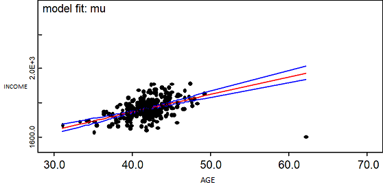

For what concerns the DIC value, there is a decrease with the t-distribution. From 3046 registered with the normal distribution, now we have 3016 that means that this model should be preferred to the other.

# Discussion

We have seen a linear regression analysis with a bayesian approach. Initially, our model had two different predictors and, thanks to the hypothesys tesisting, we were able to find out that one of them, RURAL, had no significant effects on our analysis. This led us to change our initial model to a new one and the precedent analysis was repeated. After this we were able to compare the results and we discovered that we had a really better precision on our parameter alpha and, as a consequence, we had a prediction with a smaller probability of error. In the first case alpha achieved the convergence after a huge number of MCMC simulations, instead in the second case it achieved it almost immediately.

We also focused on the differences between the bayesian approach and the inferential one. In both cases we stated that the RURAL predictor had no benefits on the regression and, for this reason, in both cases dropping that feature improved our methods.

Then we dealt with the prediction of missing values. First was selected the best model for predictions thanks to the DIC values. As we had imagined, we found that the best was the one without RURAL. Onche chosen the model, we were able to estimate the missing values and to see how good was the prediction. As before, the DIC value helped us to understand if the model used for the prediction was good or not and we discovered that it was the former.

In the last part our focus was on the outlier problem. In order to have a model that could better fit data with errors, we used a t-distribution that helped us handling that problem. We saw also that with this distribution there was also a significant decreasing in the DIC value.

# References

- [Spatio-Temporal Modeling with INLA, Data](https://sites.google.com/a/r-inla.org/stbook/datasets)
- Bayesian Data Analysis, Third Edition, 2014. Gelman, Carlin, Stern, Dunson, Vehtari, Rubin
- BAYESIAN MODELING USING WINBUGS, An Introduction. Ntzoufras

# Appendix 1

```r
list(
  N = 284,
  RURAL = c(2 , 2 , 2 , 2 , 2 , 2 , 2 , 2 , 2 , 2 , 2 , 2 , 1 , 1 , 1 , 1 , 2 , 1 , 2 , 1 , 1 , 1 , 2 , 3 , 2 , 2 , 3 , 3 , 1 , 2 , 2 , 3 , 2 , 3 , 3 , 3 , 2 , 2 , 2 , 2 , 3 , 3 , 2 , 2 , 3 , 2 , 2 , 2 , 2 , 2 , 2 , 3 , 3 , 3 , 2 , 2 , 3 , 2 , 2 , 2 , 2 , 3 , 2 , 3 , 3 , 3 , 3 , 2 , 2 , 2 , 2 , 3 , 3 , 3 , 3 , 3 , 3 , 3 , 2 , 3 , 3 , 2 , 2 , 3 , 2 , 3 , 2 , 2 , 2 , 3 , 3 , 1 , 2 , 1 , 2 , 3 , 3 , 2 , 1 , 2 , 3 , 3 , 3 , 2 , 3 , 2 , 3 , 2 , 3 , 2 , 2 , 2 , 1 , 3 , 2 , 2 , 2 , 2 , 2 , 2 , 2 , 2 , 2 , 3 , 2 , 2 , 3 , 2 , 2 , 2 , 2 , 2 , 2 , 2 , 2 , 3 , 3 , 3 , 3 , 3 , 3 , 1 , 3 , 3 , 3 , 2 , 2 , 3 , 3 , 3 , 3 , 3 , 3 , 3 , 3 , 3 , 3 , 3 , 2 , 1 , 2 , 3 , 2 , 2 , 2 , 2 , 2 , 3 , 3 , 2 , 2 , 2 , 2 , 2 , 2 , 3 , 2 , 2 , 3 , 2 , 3 , 2 , 3 , 3 , 3 , 3 , 2 , 2 , 3 , 3 , 3 , 2 , 3 , 3 , 3 , 3 , 2 , 3 , 2 , 3 , 3 , 2 , 2 , 3 , 3 , 2 , 3 , 3 , 3 , 3 , 2 , 2 , 3 , 3 , 2 , 3 , 3 , 3 , 2 , 2 , 3 , 3 , 3 , 2 , 2 , 2 , 2 , 3 , 3 , 2 , 3 , 3 , 3 , 3 , 3 , 2 , 2 , 3 , 2 , 2 , 3 , 2 , 2 , 2 , 2 , 3 , 3 , 3 , 3 , 2 , 3 , 2 , 3 , 3 , 2 , 2 , 3 , 2 , 3 , 3 , 3 , 3 , 3 , 2 , 2 , 3 , 3 , 1 , 2 , 2 , 2 , 3 , 3 , 2 , 2 , 2 , 3 , 2 , 3 , 2 , 2 , 2 , 2 , 3),
  AVAGE = c(37.44133297 , 39.35064896 , 40.60908787 , 40.73632212 , 41.42946511 , 43.08047044 , 39.39514766 , 39.7192111 , 43.27873943 , 38.77525111 , 40.5222441 , 38.21385207 , 44.89978761 , 47.62167286 , 42.52170336 , 35.14947263 , 37.92407568 , 41.5674259 , 35.45938622 , 36.72525962 , 45.05106073 , 44.45348883 , 40.7510768 , 37.99774804 , 40.15433198 , 39.39218511 , 41.37843668 , 42.08250073 , 34.11402261 , 39.81904211 , 40.97901778 , 41.30551055 , 41.26148492 , 45.0881121 , 42.27906428 , 39.5154293 , 39.01405062 , 40.23815465 , 44.17295072 , 45.81656278 , 43.21040413 , 42.02593111 , 42.18668778 , 41.95158152 , 43.98522196 , 34.48560745 , 38.10056786 , 42.92456724 , 39.41990196 , 41.01018785 , 39.39790239 , 40.91489159 , 39.55291135 , 40.32155835 , 41.39116728 , 39.55375567 , 41.98201479 , 39.49468066 , 40.54433296 , 41.25675781 , 42.71419042 , 41.5527187 , 41.17197694 , 41.61365708 , 42.54478588 , 42.17960088 , 44.25738969 , 42.44255345 , 40.71179627 , 43.95432369 , 37.49921727 , 40.70131097 , 45.71691711 , 43.51603669 , 44.30119829 , 43.75937694 , 42.47275177 , 43.11904413 , 37.78177518 , 43.22715948 , 41.81558787 , 41.58281194 , 41.79802945 , 46.65842543 , 41.62602148 , 42.76002561 , 40.69534815 , 41.87446243 , 42.17163357 , 43.79607442 , 41.65557689 , 44.8678566 , 43.31378809 , 47.94621141 , 42.7486132 , 42.55481092 , 41.42758595 , 41.50569409 , 48.36093975 , 42.95873865 , 41.61364162 , 41.78459415 , 41.64447974 , 41.79372085 , 43.64105999 , 41.77208837 , 41.80858115 , 39.78678489 , 41.31359378 , 40.71123482 , 42.62119042 , 38.48884491 , 31.12705725 , 40.20840558 , 39.49297464 , 46.16397116 , 39.85412858 , 41.99452929 , 41.33405481 , 40.35876393 , 44.62566025 , 40.03252991 , 39.9695136 , 41.33565676 , 39.81756403 , 42.72064001 , 41.28876387 , 39.38768431 , 43.05160352 , 42.96809002 , 40.94343529 , 43.59160383 , 39.45904554 , 44.34575926 , 42.67150697 , 42.05755067 , 43.06229773 , 43.20757613 , 43.07157632 , 44.42623441 , 41.11363509 , 44.65978925 , 40.72635653 , 41.3421568 , 42.3950324 , 41.82736105 , 43.22616371 , 42.66146868 , 43.72883652 , 45.12772209 , 41.08740408 , 42.80097852 , 42.21677209 , 40.78520587 , 42.1880661 , 41.41046615 , 40.72167777 , 41.98579942 , 35.2458697 , 39.32963836 , 41.48293378 , 42.30418919 , 39.63706561 , 40.79487678 , 41.07751652 , 37.02324515 , 40.43061349 , 40.7800715 , 41.33052217 , 42.54725136 , 41.61350608 , 39.65890494 , 39.23002455 , 37.20529747 , 40.63860134 , 40.88102508 , 41.1537111 , 40.41781796 , 42.58490212 , 45.09841375 , 43.54685235 , 42.88962297 , 46.48538832 , 41.6176117 , 42.08376933 , 42.39381375 , 43.71073237 , 37.34115408 , 41.26165084 , 42.63700592 , 45.88988425 , 42.3258493 , 44.38183732 , 41.31223092 , 41.15558311 , 41.47689816 , 44.48293371 , 43.47863523 , 37.06556385 , 38.73927987 , 41.89328894 , 42.05688524 , 42.53072121 , 41.05060528 , 43.25595275 , 42.29315858 , 42.98251532 , 41.87285383 , 41.45189631 , 41.76675938 , 39.30340591 , 40.63424574 , 39.99171157 , 40.14210142 , 39.59000416 , 42.59473871 , 42.1319806 , 43.94910123 , 43.11720624 , 44.734357 , 43.10707341 , 44.72965929 , 43.70145035 , 41.27855973 , 39.73829332 , 38.18096911 , 42.49325773 , 41.84430554 , 41.85528395 , 41.96904649 , 42.56184192 , 43.06669184 , 42.35054737 , 44.51535307 , 44.14812025 , 38.80604343 , 41.7762124 , 42.41665207 , 42.78646402 , 41.55144282 , 43.0673155 , 41.94570763 , 41.43214152 , 39.75989938 , 44.82621778 , 44.68024466 , 42.66733375 , 45.71268825 , 44.32129891 , 43.09486584 , 45.84243613 , 39.85367235 , 47.39159227 , 44.09293536 , 36.35786254 , 44.35226777 , 62.17312661 , 47.65593245 , 44.44976755 , 45.78145345 , 44.43665444 , 45.79587759 , 47.21220424 , 45.37826712 , 41.06562512 , 43.07791804 , 47.5442523 , 33.34478234 , 41.43800554 , 40.63591322 , 45.19813676 , 44.51323483 , 42.69732443 , 46.71838954 , 42.44475588 , 46.71337176 , 49.27959058 , 42.80804013 , 43.69489911 , 36.40798027 , 39.5178224 , 38.43414533 , 44.21812921 , 40.23107885),
  INCOME = c(1673.464653 , 1743.316626 , 1746.925286 , 1734.965722 , 1749.117707 , 1731.531099 , 1690.061536 , 1701.212968 , 1810.577196 , 1734.070045 , 1723.42157 , 1688.791274 , 1830.146696 , 1802.353797 , 1665.221241 , 1625.44067 , 1686.495166 , 1693.238369 , 1666.464131 , 1746.316858 , 1861.960772 , 1812.61673 , 1741.225675 , 1698.111151 , 1769.208308 , 1781.406117 , 1793.299135 , 1795.432877 , 1695.177574 , 1683.152051 , 1789.004839 , 1753.074772 , 1788.566584 , 1769.332102 , 1753.689898 , 1729.767522 , 1709.932417 , 1738.940092 , 1813.329319 , 1841.3619 , 1791.250023 , 1861.358731 , 1705.966466 , 1791.961144 , 1775.547533 , 1694.039788 , 1773.381924 , 1877.455773 , 1706.342084 , 1826.247333 , 1764.610971 , 1756.402633 , 1827.646086 , 1767.253348 , 1734.634028 , 1767.630887 , 1709.442958 , 1734.571244 , 1760.163398 , 1748.079478 , 1908.708712 , 1722.864704 , 1791.730035 , 1704.330113 , 1676.958294 , 1672.183718 , 1779.224393 , 1815.968396 , 1767.782021 , 1780.033013 , 1736.20791 , 1757.406799 , 1683.172718 , 1743.62761 , 1832.542529 , 1886.811174 , 1771.361515 , 1689.915712 , 1713.498016 , 1725.738356 , 1744.698151 , 1724.39664 , 1765.713157 , 1761.441846 , 1718.656039 , 1725.09545 , 1789.006696 , 1734.496206 , 1769.472639 , 1794.075277 , 1803.262792 , 1844.802329 , 1765.072232 , 1825.183916 , 1694.811577 , 1713.356393 , 1741.576912 , 1695.284944 , 1796.122856 , 1746.491573 , 1787.875117 , 1658.727599 , 1759.620787 , 1739.116442 , 1765.154712 , 1715.469509 , 1712.455427 , 1648.596451 , 1769.052069 , 1735.443578 , 1718.397047 , 1707.389638 , 1668.850033 , 1747.994662 , 1698.049707 , 1843.597262 , 1665.243526 , 1746.3297 , 1693.218888 , 1728.40522 , 1841.317994 , 1811.391284 , 1713.312716 , 1742.760648 , 1763.507906 , 1784.035096 , 1741.184137 , 1668.145149 , 1763.167749 , 1860.614031 , 1773.042304 , 1763.319093 , 1745.854732 , 1856.052323 , 1802.466931 , 1765.981647 , 1743.212089 , 1756.13476 , 1844.517069 , 1762.388111 , 1827.720865 , 1888.541826 , 1746.885709 , 1765.029868 , 1752.922532 , 1720.320493 , 1653.855496 , 1737.210844 , 1833.867699 , 1909.259587 , 1822.513801 , 1749.765724 , 1735.240433 , 1774.410537 , 1871.862994 , 1865.712931 , 1798.335293 , 1743.42355 , 1689.534056 , 1735.526667 , 1765.484298 , 1755.148953 , 1728.222471 , 1873.630695 , 1748.852255 , 1733.994625 , 1761.445782 , 1769.461168 , 1751.029209 , 1754.364338 , 1717.486134 , 1792.055311 , 1794.699102 , 1663.629716 , 1742.781203 , 1746.35858 , 1772.393412 , 1760.585461 , 1793.279601 , 1725.757316 , 1724.878277 , 1859.55669 , 1761.522734 , 1839.881505 , 1818.327477 , 1724.19656 , 1745.430627 , 1727.01547 , 1759.830619 , 1716.154127 , 1845.381933 , 1768.222499 , 1817.900216 , 1808.842537 , 1664.19609 , 1790.309413 , 1856.568815 , 1767.302963 , 1662.313563 , 1715.124794 , 1807.065207 , 1776.572851 , 1788.266121 , 1732.312718 , 1756.524941 , 1796.870093 , 1875.750769 , 1775.447933 , 1759.226294 , 1782.186774 , 1763.644643 , 1734.217891 , 1761.096885 , 1726.487532 , 1743.010783 , 1776.180056 , 1812.907637 , 1786.710271 , 1765.171539 , 1794.140631 , 1813.209991 , 1852.12082 , 1708.159516 , 1794.444436 , 1735.741297 , 1664.689557 , 1735.85746 , 1639.329931 , 1757.065906 , 1760.70498 , 1741.066115 , 1721.912972 , 1858.352132 , 1816.756202 , 1876.718746 , 1754.384831 , 1766.571372 , 1905.039156 , 1730.896972 , 1792.842137 , 1801.47168 , 1750.883134 , 1746.516368 , 1750.606409 , 1781.041153 , 1816.056608 , 1807.071424 , 1776.356504 , 1723.955403 , 1817.525554 , 1798.265744 , 1782.706233 , 1910.011551 , 1778.049576 , 1747.724152 , 1761.273976 , 1600 , 1779.621032 , 1806.618039 , 1838.517289 , 1790.694033 , 1781.990534 , 1836.941555 , 1728.748209 , 1813.283766 , 1797.547598 , 1816.064961 , 1689.492907 , 1823.719012 , 1734.293914 , 1766.641745 , 1735.668314 , 1818.90199 , 1870.604582 , 1758.192953 , 1830.932385 , 1852.230048 , 1782.032513 , 1846.255374 , 1732.741571 , 1714.602098 , 1789.826697 , 1835.506076 , 1816.722808)

)
```